# Johansen_Van_Topic_4

Access "DSC-550-RS-Project4" for successful completion of this assignment.

APA style is not required, but solid academic writing is expected.

This assignment uses a rubric. Please review the rubric prior to beginning the assignment to become familiar with the expectations for successful completion.

Submit a Microsoft Word document, including the source code and how you automated the testing. Complete this by hand and then write a code to compute the different points for (a), (b) and (c).

Zip your document, including the source code, and submit to LoudCloud, as directed by your instructor.

You are required to submit this assignment to LopesWrite. Refer to the LopesWrite Technical Support articles for assistance.

1. Draw a decision boundary.
2. Find the weight and bias values that result in a single-neuron perceptron with the chosen decision boundaries. Observe the fitting model data to a training data set.
3. How would you find the variance for this problem case?
4. Check your solution (post-training data) against the original points.
5. Use Python and the corresponding libraries to automate the testing process, and to try new points.

## Part A

```python
# Install Libraries and dependencies
import pandas as pd
import numpy as np
from sklearn.datasets import make_blobs
from matplotlib import pyplot
import neurolab as nl
```

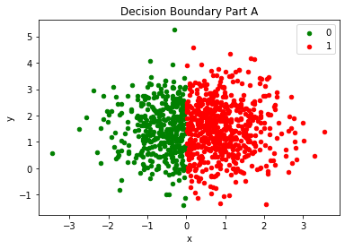

```python
# part A Data
# generate 2d classification dataset
X, y = make_blobs(n_samples=1000, center_box=[-2,2], n_features=2, centers=1)
z = []
for i in range(0, len(X)):
    if (X[:,0][i] <= 0):
        z.append(0)
    else:
        z.append(1)

# scatter plot, dots colored by class value
df_part_a = pd.DataFrame(dict(x=X[:,0], y=X[:,1], label=z))
colors = {0:'green', 1:'red'}
fig, ax = pyplot.subplots()
grouped = df_part_a.groupby('label')
for key, group in grouped:
    group.plot(ax=ax, kind='scatter', x='x', y='y', label=key, color=colors[key])
pyplot.title('Decision Boundary Part A')
pyplot.show()
```

```python
# Set up data and set up neural net
input_dat = X
target = []
for v in z:
    target.append([v])

# Create net with 2 inputs and 1 neuron
net = nl.net.newp([[0, 1],[0, 1]], 1)
net.layers[-1].transf = nl.trans.HardLim()
```

```python
# Train Neural Net
error = net.train(input_dat[:800], target[:800], epochs=500, goal=0.1)
print("Finish error: ", error[-1])

# Number of network inputs:
print("Number of network inputs: ", net.ci)

# Number of network outputs:
print("Number of network outputs: ", net.co)

# Number of network layers:
print("Number of network layers: ", len(net.layers))

# Weight of first neuron of input layer (net.layers[0])
print("Weight of neuron: ", net.layers[0].np['w'])

# Bias output layer:
print("Bias output layer: ", net.layers[-1].np['b'])

# Run on Test Set - Automation
net.layers[-1].transf = nl.trans.HardLim()

preds = net.sim(input_dat[800:])

# variance calculation
print("Variance: ", np.var(preds))
```

```
The goal of learning is reached
Finish error:  0.0
Number of network inputs:  2
Number of network outputs:  1
Number of network layers:  1
Weight of neuron:  [[ 0.13110883 -0.00031881]]
Bias output layer:  [0.]
Variance:  0.2379
```

## Part B

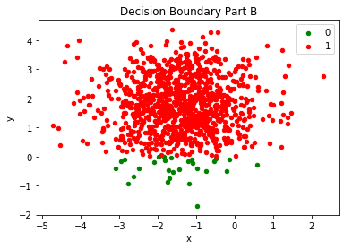

```python
# part B Data
from sklearn.datasets import make_blobs
from matplotlib import pyplot
from pandas import DataFrame
# generate 2d classification dataset
X, y = make_blobs(n_samples=1000, center_box=[-2,2], n_features=2, centers=1)
z = []
for i in range(0, len(X)):
    if (X[:,1][i] <= 0):
        z.append(0)
    else:
        z.append(1)

# scatter plot, dots colored by class value
df_part_b = DataFrame(dict(x=X[:,0], y=X[:,1], label=z))
colors = {0:'green', 1:'red'}
fig, ax = pyplot.subplots()
grouped = df_part_b.groupby('label')
for key, group in grouped:
    group.plot(ax=ax, kind='scatter', x='x', y='y', label=key, color=colors[key])
pyplot.title('Decision Boundary Part B')
pyplot.show()
```

```python
# Set up data and set up neural net
input_dat = X
target = []
for v in z:
    target.append([v])

# Create net with 2 inputs and 1 neuron
net = nl.net.newp([[0, 1],[0, 1]], 1)
net.layers[-1].transf = nl.trans.HardLim()
```

```python
# Train Neural Net
error = net.train(input_dat[:800], target[:800], epochs=500, goal=0.1)
print("Finish error: ", error[-1])

# Number of network inputs:
print("Number of network inputs: ", net.ci)

# Number of network outputs:
print("Number of network outputs: ", net.co)

# Number of network layers:
print("Number of network layers: ", len(net.layers))

# Weight of first neuron of input layer (net.layers[0])
print("Weight of neuron: ", net.layers[0].np['w'])

# Bias output layer:
print("Bias output layer: ", net.layers[-1].np['b'])

# Run on Test Set - Automation
net.layers[-1].transf = nl.trans.HardLim()

preds = net.sim(input_dat[800:])

# variance calculation
print("Variance: ", np.var(preds))
```

```
The goal of learning is reached
Finish error:  0.0
Number of network inputs:  2
Number of network outputs:  1
Number of network layers:  1
Weight of neuron:  [[-0.00059208  0.06775823]]
Bias output layer:  [0.]
Variance:  0.024375000000000004
```

## Part C

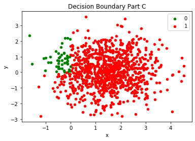

```python
# part C Data
from sklearn.datasets import make_blobs
from matplotlib import pyplot
from pandas import DataFrame
# generate 2d classification dataset
X, y = make_blobs(n_samples=1000, center_box=[-2,2], n_features=2, centers=1)
z = []
for i in range(0, len(X)):
    if ((X[:,0][i] < 0) and (X[:,1][i] > 0)):
        z.append(0)
    else:
        z.append(1)

# scatter plot, dots colored by class value
df_part_c = DataFrame(dict(x=X[:,0], y=X[:,1], label=z))
colors = {0:'green', 1:'red'}
fig, ax = pyplot.subplots()
grouped = df_part_c.groupby('label')
for key, group in grouped:
    group.plot(ax=ax, kind='scatter', x='x', y='y', label=key, color=colors[key])
pyplot.title('Decision Boundary Part C')
pyplot.show()
```

```python
# Set up data and set up neural net
input_dat = X
target = []
for v in z:
    target.append([v])

# Create net with 2 inputs and 1 neuron
net = nl.net.newp([[0, 1],[0, 1]], 1)
net.layers[-1].transf = nl.trans.HardLim()
```

```python
# Train Neural Net
error = net.train(input_dat[:800], target[:800], epochs=500, goal=0.1)
print("Finish error: ", error[-1])

# Number of network inputs:
print("Number of network inputs: ", net.ci)

# Number of network outputs:
print("Number of network outputs: ", net.co)

# Number of network layers:
print("Number of network layers: ", len(net.layers))

# Weight of first neuron of input layer (net.layers[0])
print("Weight of neuron: ", net.layers[0].np['w'])

# Bias output layer:
print("Bias output layer: ", net.layers[-1].np['b'])

# Run on Test Set - Automation
preds = net.sim(input_dat[800:])

# variance calculation
print("Variance: ", np.var(preds))
```

```
Epoch: 100; Error: 10.0;
Epoch: 200; Error: 8.5;
Epoch: 300; Error: 9.0;
Epoch: 400; Error: 8.5;
Epoch: 500; Error: 10.5;
The maximum number of train epochs is reached
Finish error:  10.5
Number of network inputs:  2
Number of network outputs:  1
Number of network layers:  1
Weight of neuron:  [[ 0.06054837 -0.0183337 ]]
Bias output layer:  [0.02]
Variance:  0.051975000000000014
```

##### Analysis / Write Up

In the above code, neural nets were built for the 3 different scenarios outlined in the assignment. These nets have a HardLim layer as requested as well. After plotting out the decision boundaries, we train the neural nets on an 80 / 20 split, and the weights, bias, and variance are printed. The test data was also used and the process has been automated.

#### References

Anwar, A. (2020, November 6). Understanding the Bias-Variance Tradeoff and visualizing it with example and python code. Retrieved from https://towardsdatascience.com/understanding-the-bias-variance-tradeoff-and-visualizing-it-with-example-and-python-code-7af2681a10a7

Kathuria, A. (2019, December 2). Intro to optimization in deep learning: Gradient Descent. Retrieved from https://blog.paperspace.com/intro-to-optimization-in-deep-learning-gradient-descent/

Neural Network Bias: Bias Neuron, Overfitting and Underfitting. (2020). Retrieved from https://missinglink.ai/guides/neural-network-concepts/neural-network-bias-bias-neuron-overfitting-underfitting/

Ruder, S. (2020, March 20). An overview of gradient descent optimization algorithms. Retrieved from https://ruder.io/optimizing-gradient-descent/

Welcome to NeuroLab’s documentation! — NeuroLab 0.3.5 documentation. (2020). Retrieved from https://pythonhosted.org/neurolab/